# Risk Factor Analysis

## Outcome Variable

**Outcome Variable:** ever_stunted

## Predictor Variables

**Intervention Variable:** meducyrs

**Adjustment Set:**

unadjusted

## Stratifying Variables

The analysis was stratified on these variable(s):

- agecat
- studyid
- country

## Data Summary

| agecat | studyid | country | meducyrs | ever_stunted | n_cell | n |
| --- | --- | --- | --- | --- | --- | --- |
| 0-6 months | ki0047075b-MAL-ED | BANGLADESH | Q4 | 0 | 57 | 214 |
| 0-6 months | ki0047075b-MAL-ED | BANGLADESH | Q4 | 1 | 4 | 214 |
| 0-6 months | ki0047075b-MAL-ED | BANGLADESH | Q1 | 0 | 29 | 214 |
| 0-6 months | ki0047075b-MAL-ED | BANGLADESH | Q1 | 1 | 13 | 214 |
| 0-6 months | ki0047075b-MAL-ED | BANGLADESH | Q2 | 0 | 23 | 214 |
| 0-6 months | ki0047075b-MAL-ED | BANGLADESH | Q2 | 1 | 5 | 214 |
| 0-6 months | ki0047075b-MAL-ED | BANGLADESH | Q3 | 0 | 68 | 214 |
| 0-6 months | ki0047075b-MAL-ED | BANGLADESH | Q3 | 1 | 15 | 214 |
| 0-6 months | ki0047075b-MAL-ED | BRAZIL | Q4 | 0 | 71 | 232 |
| 0-6 months | ki0047075b-MAL-ED | BRAZIL | Q4 | 1 | 8 | 232 |
| 0-6 months | ki0047075b-MAL-ED | BRAZIL | Q1 | 0 | 44 | 232 |
| 0-6 months | ki0047075b-MAL-ED | BRAZIL | Q1 | 1 | 3 | 232 |
| 0-6 months | ki0047075b-MAL-ED | BRAZIL | Q2 | 0 | 36 | 232 |
| 0-6 months | ki0047075b-MAL-ED | BRAZIL | Q2 | 1 | 8 | 232 |
| 0-6 months | ki0047075b-MAL-ED | BRAZIL | Q3 | 0 | 56 | 232 |
| 0-6 months | ki0047075b-MAL-ED | BRAZIL | Q3 | 1 | 6 | 232 |
| 0-6 months | ki0047075b-MAL-ED | INDIA | Q4 | 0 | 53 | 220 |
| 0-6 months | ki0047075b-MAL-ED | INDIA | Q4 | 1 | 10 | 220 |
| 0-6 months | ki0047075b-MAL-ED | INDIA | Q1 | 0 | 31 | 220 |
| 0-6 months | ki0047075b-MAL-ED | INDIA | Q1 | 1 | 4 | 220 |
| 0-6 months | ki0047075b-MAL-ED | INDIA | Q2 | 0 | 44 | 220 |
| 0-6 months | ki0047075b-MAL-ED | INDIA | Q2 | 1 | 8 | 220 |
| 0-6 months | ki0047075b-MAL-ED | INDIA | Q3 | 0 | 57 | 220 |
| 0-6 months | ki0047075b-MAL-ED | INDIA | Q3 | 1 | 13 | 220 |
| 0-6 months | ki0047075b-MAL-ED | NEPAL | Q4 | 0 | 16 | 225 |
| 0-6 months | ki0047075b-MAL-ED | NEPAL | Q4 | 1 | 4 | 225 |
| 0-6 months | ki0047075b-MAL-ED | NEPAL | Q1 | 0 | 28 | 225 |
| 0-6 months | ki0047075b-MAL-ED | NEPAL | Q1 | 1 | 2 | 225 |
| 0-6 months | ki0047075b-MAL-ED | NEPAL | Q2 | 0 | 55 | 225 |
| 0-6 months | ki0047075b-MAL-ED | NEPAL | Q2 | 1 | 11 | 225 |

[output cut: 588 more lines]

The following strata were considered:

- agecat: 0-24 months, studyid: ki0047075b-MAL-ED, country: BANGLADESH
- agecat: 0-24 months, studyid: ki0047075b-MAL-ED, country: BRAZIL
- agecat: 0-24 months, studyid: ki0047075b-MAL-ED, country: INDIA
- agecat: 0-24 months, studyid: ki0047075b-MAL-ED, country: NEPAL
- agecat: 0-24 months, studyid: ki0047075b-MAL-ED, country: PERU
- agecat: 0-24 months, studyid: ki0047075b-MAL-ED, country: SOUTH AFRICA
- agecat: 0-24 months, studyid: ki0047075b-MAL-ED, country: TANZANIA, UNITED REPUBLIC OF
- agecat: 0-24 months, studyid: ki1000108-CMC-V-BCS-2002, country: INDIA
- agecat: 0-24 months, studyid: ki1000108-IRC, country: INDIA
- agecat: 0-24 months, studyid: ki1000109-EE, country: PAKISTAN
- agecat: 0-24 months, studyid: ki1000304b-SAS-CompFeed, country: INDIA
- agecat: 0-24 months, studyid: ki1000304b-SAS-FoodSuppl, country: INDIA
- agecat: 0-24 months, studyid: ki1017093-NIH-Birth, country: BANGLADESH
- agecat: 0-24 months, studyid: ki1017093b-PROVIDE, country: BANGLADESH
- agecat: 0-24 months, studyid: ki1017093c-NIH-Crypto, country: BANGLADESH
- agecat: 0-24 months, studyid: ki1066203-TanzaniaChild2, country: TANZANIA, UNITED REPUBLIC OF
- agecat: 0-24 months, studyid: ki1112895-Guatemala BSC, country: GUATEMALA
- agecat: 0-24 months, studyid: ki1113344-GMS-Nepal, country: NEPAL
- agecat: 0-24 months, studyid: ki1119695-PROBIT, country: BELARUS
- agecat: 0-24 months, studyid: ki1126311-ZVITAMBO, country: ZIMBABWE
- agecat: 0-24 months, studyid: ki1135781-COHORTS, country: GUATEMALA
- agecat: 0-24 months, studyid: ki1135781-COHORTS, country: INDIA
- agecat: 0-24 months, studyid: ki1135781-COHORTS, country: PHILIPPINES
- agecat: 0-24 months, studyid: ki1148112-LCNI-5, country: MALAWI
- agecat: 0-24 months, studyid: kiGH5241-JiVitA-3, country: BANGLADESH
- agecat: 0-24 months, studyid: kiGH5241-JiVitA-4, country: BANGLADESH
- agecat: 0-6 months, studyid: ki0047075b-MAL-ED, country: BANGLADESH
- agecat: 0-6 months, studyid: ki0047075b-MAL-ED, country: BRAZIL
- agecat: 0-6 months, studyid: ki0047075b-MAL-ED, country: INDIA
- agecat: 0-6 months, studyid: ki0047075b-MAL-ED, country: NEPAL
- agecat: 0-6 months, studyid: ki0047075b-MAL-ED, country: PERU
- agecat: 0-6 months, studyid: ki0047075b-MAL-ED, country: SOUTH AFRICA
- agecat: 0-6 months, studyid: ki0047075b-MAL-ED, country: TANZANIA, UNITED REPUBLIC OF
- agecat: 0-6 months, studyid: ki1000108-CMC-V-BCS-2002, country: INDIA
- agecat: 0-6 months, studyid: ki1000108-IRC, country: INDIA
- agecat: 0-6 months, studyid: ki1000109-EE, country: PAKISTAN
- agecat: 0-6 months, studyid: ki1000304b-SAS-CompFeed, country: INDIA
- agecat: 0-6 months, studyid: ki1000304b-SAS-FoodSuppl, country: INDIA
- agecat: 0-6 months, studyid: ki1017093-NIH-Birth, country: BANGLADESH
- agecat: 0-6 months, studyid: ki1017093b-PROVIDE, country: BANGLADESH
- agecat: 0-6 months, studyid: ki1017093c-NIH-Crypto, country: BANGLADESH
- agecat: 0-6 months, studyid: ki1066203-TanzaniaChild2, country: TANZANIA, UNITED REPUBLIC OF
- agecat: 0-6 months, studyid: ki1112895-Guatemala BSC, country: GUATEMALA
- agecat: 0-6 months, studyid: ki1113344-GMS-Nepal, country: NEPAL
- agecat: 0-6 months, studyid: ki1119695-PROBIT, country: BELARUS
- agecat: 0-6 months, studyid: ki1126311-ZVITAMBO, country: ZIMBABWE
- agecat: 0-6 months, studyid: ki1135781-COHORTS, country: GUATEMALA
- agecat: 0-6 months, studyid: ki1135781-COHORTS, country: INDIA
- agecat: 0-6 months, studyid: ki1135781-COHORTS, country: PHILIPPINES
- agecat: 0-6 months, studyid: ki1148112-LCNI-5, country: MALAWI
- agecat: 0-6 months, studyid: kiGH5241-JiVitA-3, country: BANGLADESH
- agecat: 0-6 months, studyid: kiGH5241-JiVitA-4, country: BANGLADESH
- agecat: 6-24 months, studyid: ki0047075b-MAL-ED, country: BANGLADESH
- agecat: 6-24 months, studyid: ki0047075b-MAL-ED, country: BRAZIL
- agecat: 6-24 months, studyid: ki0047075b-MAL-ED, country: INDIA
- agecat: 6-24 months, studyid: ki0047075b-MAL-ED, country: NEPAL
- agecat: 6-24 months, studyid: ki0047075b-MAL-ED, country: PERU
- agecat: 6-24 months, studyid: ki0047075b-MAL-ED, country: SOUTH AFRICA
- agecat: 6-24 months, studyid: ki0047075b-MAL-ED, country: TANZANIA, UNITED REPUBLIC OF
- agecat: 6-24 months, studyid: ki1000108-CMC-V-BCS-2002, country: INDIA
- agecat: 6-24 months, studyid: ki1000108-IRC, country: INDIA
- agecat: 6-24 months, studyid: ki1000109-EE, country: PAKISTAN
- agecat: 6-24 months, studyid: ki1000304b-SAS-CompFeed, country: INDIA
- agecat: 6-24 months, studyid: ki1000304b-SAS-FoodSuppl, country: INDIA
- agecat: 6-24 months, studyid: ki1017093-NIH-Birth, country: BANGLADESH
- agecat: 6-24 months, studyid: ki1017093b-PROVIDE, country: BANGLADESH
- agecat: 6-24 months, studyid: ki1017093c-NIH-Crypto, country: BANGLADESH
- agecat: 6-24 months, studyid: ki1066203-TanzaniaChild2, country: TANZANIA, UNITED REPUBLIC OF
- agecat: 6-24 months, studyid: ki1112895-Guatemala BSC, country: GUATEMALA
- agecat: 6-24 months, studyid: ki1113344-GMS-Nepal, country: NEPAL
- agecat: 6-24 months, studyid: ki1119695-PROBIT, country: BELARUS
- agecat: 6-24 months, studyid: ki1126311-ZVITAMBO, country: ZIMBABWE
- agecat: 6-24 months, studyid: ki1135781-COHORTS, country: GUATEMALA
- agecat: 6-24 months, studyid: ki1135781-COHORTS, country: INDIA
- agecat: 6-24 months, studyid: ki1135781-COHORTS, country: PHILIPPINES
- agecat: 6-24 months, studyid: ki1148112-LCNI-5, country: MALAWI
- agecat: 6-24 months, studyid: kiGH5241-JiVitA-3, country: BANGLADESH
- agecat: 6-24 months, studyid: kiGH5241-JiVitA-4, country: BANGLADESH

### Dropped Strata

Some strata were dropped due to rare outcomes:

- agecat: 0-6 months, studyid: ki0047075b-MAL-ED, country: BANGLADESH
- agecat: 0-6 months, studyid: ki0047075b-MAL-ED, country: BRAZIL
- agecat: 0-6 months, studyid: ki0047075b-MAL-ED, country: INDIA
- agecat: 0-6 months, studyid: ki0047075b-MAL-ED, country: NEPAL
- agecat: 0-6 months, studyid: ki0047075b-MAL-ED, country: SOUTH AFRICA
- agecat: 0-6 months, studyid: ki0047075b-MAL-ED, country: TANZANIA, UNITED REPUBLIC OF
- agecat: 0-6 months, studyid: ki1000108-CMC-V-BCS-2002, country: INDIA
- agecat: 0-6 months, studyid: ki1000108-IRC, country: INDIA
- agecat: 0-6 months, studyid: ki1000109-EE, country: PAKISTAN
- agecat: 0-6 months, studyid: ki1017093b-PROVIDE, country: BANGLADESH
- agecat: 0-6 months, studyid: ki1066203-TanzaniaChild2, country: TANZANIA, UNITED REPUBLIC OF
- agecat: 0-6 months, studyid: ki1113344-GMS-Nepal, country: NEPAL
- agecat: 0-6 months, studyid: ki1119695-PROBIT, country: BELARUS
- agecat: 0-6 months, studyid: ki1135781-COHORTS, country: GUATEMALA
- agecat: 0-6 months, studyid: ki1148112-LCNI-5, country: MALAWI
- agecat: 6-24 months, studyid: ki0047075b-MAL-ED, country: BRAZIL
- agecat: 6-24 months, studyid: ki0047075b-MAL-ED, country: NEPAL
- agecat: 6-24 months, studyid: ki0047075b-MAL-ED, country: TANZANIA, UNITED REPUBLIC OF
- agecat: 6-24 months, studyid: ki1000108-IRC, country: INDIA
- agecat: 6-24 months, studyid: ki1000109-EE, country: PAKISTAN
- agecat: 6-24 months, studyid: ki1000304b-SAS-CompFeed, country: INDIA
- agecat: 6-24 months, studyid: ki1017093b-PROVIDE, country: BANGLADESH
- agecat: 6-24 months, studyid: ki1017093c-NIH-Crypto, country: BANGLADESH
- agecat: 6-24 months, studyid: ki1066203-TanzaniaChild2, country: TANZANIA, UNITED REPUBLIC OF
- agecat: 6-24 months, studyid: ki1112895-Guatemala BSC, country: GUATEMALA
- agecat: 6-24 months, studyid: ki1119695-PROBIT, country: BELARUS
- agecat: 6-24 months, studyid: ki1135781-COHORTS, country: GUATEMALA
- agecat: 6-24 months, studyid: ki1148112-LCNI-5, country: MALAWI
- agecat: 6-24 months, studyid: kiGH5241-JiVitA-4, country: BANGLADESH
- agecat: 0-24 months, studyid: ki0047075b-MAL-ED, country: TANZANIA, UNITED REPUBLIC OF
- agecat: 0-24 months, studyid: ki1000108-IRC, country: INDIA
- agecat: 0-24 months, studyid: ki1000109-EE, country: PAKISTAN
- agecat: 0-24 months, studyid: ki1017093b-PROVIDE, country: BANGLADESH
- agecat: 0-24 months, studyid: ki1066203-TanzaniaChild2, country: TANZANIA, UNITED REPUBLIC OF
- agecat: 0-24 months, studyid: ki1135781-COHORTS, country: GUATEMALA
- agecat: 0-24 months, studyid: ki1148112-LCNI-5, country: MALAWI

## Methods Detail

We’re interested in the causal parameters $E[Y_a]$ for all values of $a \in \mathcal{A}$. These parameters represent the mean outcome if, possibly contrary to fact, we intervened to set all units to have $A=a$. Under the randomization and positivity assumptions, these are identified by the statistical parameters $\psi_a=E_W[E_{Y|A,W}(Y|A=a,W)]$. In addition, we’re interested in the mean of $Y$, $E[Y]$ under no intervention (the observed mean). We will estimate these parameters by using SuperLearner to fit the relevant likelihood factors – $E_{Y|A,W}(Y|A=a,W)$ and $p(A=a|W)$, and then updating our likelihood fit using a joint TMLE.

For unadjusted analyses ($W=\{\}$), initial likelihoods were estimated using Lrnr_glm to estimate the simple $E(Y|A)$ and Lrnr_mean to estimate $p(A)$. For adjusted analyses, a small library containing Lrnr_glmnet, Lrnr_xgboost, and Lrnr_mean was used.

Having estimated these parameters, we will then use the delta method to estimate relative risks and attributable risks relative to a prespecified baseline level of $A$.

```
##         ever_stunted
## meducyrs    0
##       Q4 1720
##       Q1 1274
##       Q2  711
##       Q3  718
```

# Results Detail

## Results Plots

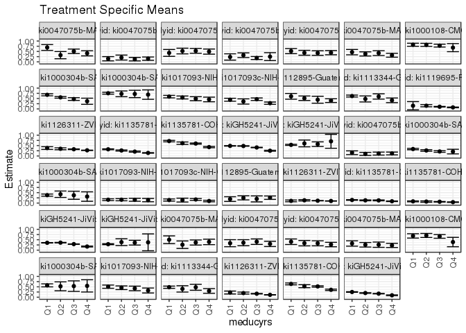

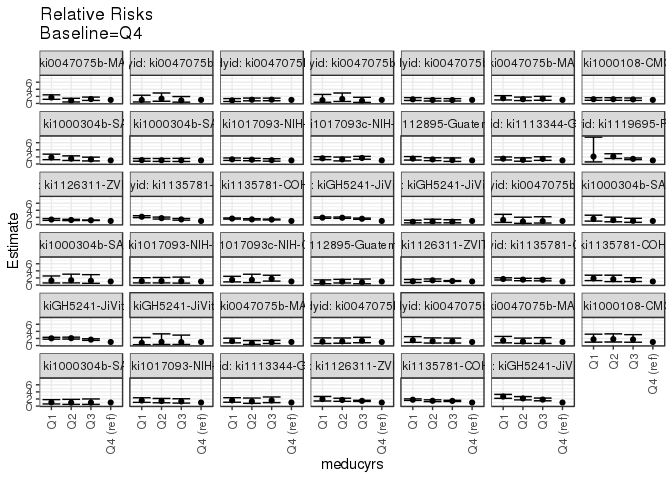

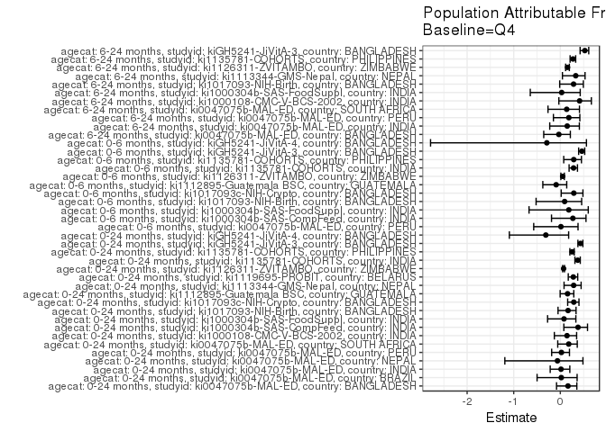

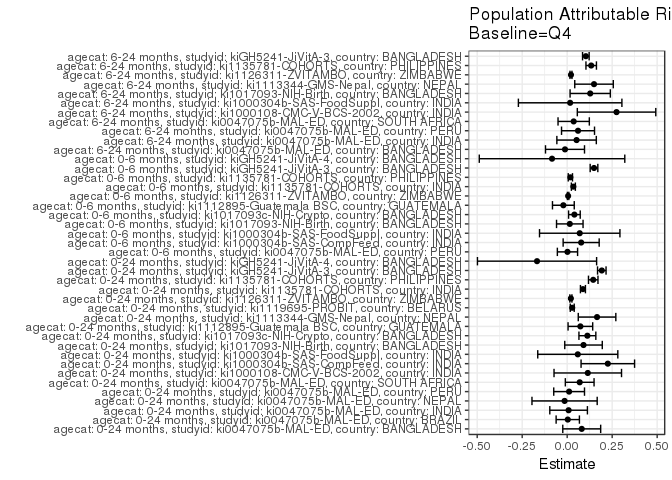

## Results Table

### Parameter: TSM

| agecat | studyid | country | intervention_level | baseline_level | estimate | ci_lower | ci_upper |
| --- | --- | --- | --- | --- | --- | --- | --- |
| 0-24 months | ki0047075b-MAL-ED | BANGLADESH | Q4 | NA | 0.4098361 | 0.2861298 | 0.5335423 |
| 0-24 months | ki0047075b-MAL-ED | BANGLADESH | Q1 | NA | 0.6904762 | 0.5503363 | 0.8306161 |
| 0-24 months | ki0047075b-MAL-ED | BANGLADESH | Q2 | NA | 0.3214286 | 0.1480377 | 0.4948194 |
| 0-24 months | ki0047075b-MAL-ED | BANGLADESH | Q3 | NA | 0.5060241 | 0.3982127 | 0.6138355 |
| 0-24 months | ki0047075b-MAL-ED | BRAZIL | Q4 | NA | 0.1518987 | 0.0725804 | 0.2312170 |
| 0-24 months | ki0047075b-MAL-ED | BRAZIL | Q1 | NA | 0.1489362 | 0.0469319 | 0.2509404 |
| 0-24 months | ki0047075b-MAL-ED | BRAZIL | Q2 | NA | 0.2045455 | 0.0851020 | 0.3239889 |
| 0-24 months | ki0047075b-MAL-ED | BRAZIL | Q3 | NA | 0.1290323 | 0.0454064 | 0.2126581 |
| 0-24 months | ki0047075b-MAL-ED | INDIA | Q4 | NA | 0.4920635 | 0.3683314 | 0.6157956 |
| 0-24 months | ki0047075b-MAL-ED | INDIA | Q1 | NA | 0.4285714 | 0.2642493 | 0.5928935 |
| 0-24 months | ki0047075b-MAL-ED | INDIA | Q2 | NA | 0.5192308 | 0.3831226 | 0.6553390 |
| 0-24 months | ki0047075b-MAL-ED | INDIA | Q3 | NA | 0.5285714 | 0.4113659 | 0.6457770 |
| 0-24 months | ki0047075b-MAL-ED | NEPAL | Q4 | NA | 0.2500000 | 0.0598042 | 0.4401958 |
| 0-24 months | ki0047075b-MAL-ED | NEPAL | Q1 | NA | 0.2333333 | 0.0816470 | 0.3850196 |
| 0-24 months | ki0047075b-MAL-ED | NEPAL | Q2 | NA | 0.3181818 | 0.2055619 | 0.4308018 |
| 0-24 months | ki0047075b-MAL-ED | NEPAL | Q3 | NA | 0.1834862 | 0.1106604 | 0.2563121 |
| 0-24 months | ki0047075b-MAL-ED | PERU | Q4 | NA | 0.4395604 | 0.3374145 | 0.5417064 |
| 0-24 months | ki0047075b-MAL-ED | PERU | Q1 | NA | 0.5156250 | 0.3929839 | 0.6382661 |
| 0-24 months | ki0047075b-MAL-ED | PERU | Q2 | NA | 0.4347826 | 0.3176204 | 0.5519448 |
| 0-24 months | ki0047075b-MAL-ED | PERU | Q3 | NA | 0.4230769 | 0.3132549 | 0.5328990 |
| 0-24 months | ki0047075b-MAL-ED | SOUTH AFRICA | Q4 | NA | 0.3157895 | 0.2221686 | 0.4094103 |
| 0-24 months | ki0047075b-MAL-ED | SOUTH AFRICA | Q1 | NA | 0.4655172 | 0.3369408 | 0.5940937 |
| 0-24 months | ki0047075b-MAL-ED | SOUTH AFRICA | Q2 | NA | 0.3804348 | 0.2810705 | 0.4797991 |
| 0-24 months | ki0047075b-MAL-ED | SOUTH AFRICA | Q3 | NA | 0.4202899 | 0.3036368 | 0.5369429 |
| 0-24 months | ki1000108-CMC-V-BCS-2002 | INDIA | Q4 | NA | 0.6818182 | 0.4869272 | 0.8767091 |
| 0-24 months | ki1000108-CMC-V-BCS-2002 | INDIA | Q1 | NA | 0.8207547 | 0.7476393 | 0.8938701 |
| 0-24 months | ki1000108-CMC-V-BCS-2002 | INDIA | Q2 | NA | 0.8165138 | 0.7437523 | 0.8892752 |
| 0-24 months | ki1000108-CMC-V-BCS-2002 | INDIA | Q3 | NA | 0.7794118 | 0.7096309 | 0.8491926 |
| 0-24 months | ki1000304b-SAS-CompFeed | INDIA | Q4 | NA | 0.3684211 | 0.2207803 | 0.5160618 |
| 0-24 months | ki1000304b-SAS-CompFeed | INDIA | Q1 | NA | 0.6779891 | 0.6293807 | 0.7265975 |

[output cut: 134 more lines]

### Parameter: E(Y)

| agecat | studyid | country | intervention_level | baseline_level | estimate | ci_lower | ci_upper |
| --- | --- | --- | --- | --- | --- | --- | --- |
| 0-24 months | ki0047075b-MAL-ED | BANGLADESH | NA | NA | 0.4906542 | 0.4235187 | 0.5577897 |
| 0-24 months | ki0047075b-MAL-ED | BRAZIL | NA | NA | 0.1551724 | 0.1084814 | 0.2018634 |
| 0-24 months | ki0047075b-MAL-ED | INDIA | NA | NA | 0.5000000 | 0.4337790 | 0.5662210 |
| 0-24 months | ki0047075b-MAL-ED | NEPAL | NA | NA | 0.2355556 | 0.1799851 | 0.2911260 |
| 0-24 months | ki0047075b-MAL-ED | PERU | NA | NA | 0.4503311 | 0.3941253 | 0.5065370 |
| 0-24 months | ki0047075b-MAL-ED | SOUTH AFRICA | NA | NA | 0.3853503 | 0.3314343 | 0.4392663 |
| 0-24 months | ki1000108-CMC-V-BCS-2002 | INDIA | NA | NA | 0.7962466 | 0.7553156 | 0.8371777 |
| 0-24 months | ki1000304b-SAS-CompFeed | INDIA | NA | NA | 0.5942596 | 0.5539147 | 0.6346046 |
| 0-24 months | ki1000304b-SAS-FoodSuppl | INDIA | NA | NA | 0.7464115 | 0.7046540 | 0.7881689 |
| 0-24 months | ki1017093-NIH-Birth | BANGLADESH | NA | NA | 0.5453100 | 0.5063654 | 0.5842547 |
| 0-24 months | ki1017093c-NIH-Crypto | BANGLADESH | NA | NA | 0.3878628 | 0.3531521 | 0.4225735 |
| 0-24 months | ki1112895-Guatemala BSC | GUATEMALA | NA | NA | 0.4716312 | 0.4132646 | 0.5299979 |
| 0-24 months | ki1113344-GMS-Nepal | NEPAL | NA | NA | 0.5792988 | 0.5397316 | 0.6188661 |
| 0-24 months | ki1119695-PROBIT | BELARUS | NA | NA | 0.1006096 | 0.0848963 | 0.1163228 |
| 0-24 months | ki1126311-ZVITAMBO | ZIMBABWE | NA | NA | 0.2928200 | 0.2852961 | 0.3003440 |
| 0-24 months | ki1135781-COHORTS | INDIA | NA | NA | 0.2344498 | 0.2235944 | 0.2453051 |
| 0-24 months | ki1135781-COHORTS | PHILIPPINES | NA | NA | 0.5716154 | 0.5540738 | 0.5891570 |
| 0-24 months | kiGH5241-JiVitA-3 | BANGLADESH | NA | NA | 0.4437909 | 0.4362664 | 0.4513154 |
| 0-24 months | kiGH5241-JiVitA-4 | BANGLADESH | NA | NA | 0.5383615 | 0.5136968 | 0.5630262 |
| 0-6 months | ki0047075b-MAL-ED | PERU | NA | NA | 0.1225166 | 0.0854756 | 0.1595575 |
| 0-6 months | ki1000304b-SAS-CompFeed | INDIA | NA | NA | 0.2882353 | 0.2618269 | 0.3146436 |
| 0-6 months | ki1000304b-SAS-FoodSuppl | INDIA | NA | NA | 0.3822115 | 0.3354600 | 0.4289631 |
| 0-6 months | ki1017093-NIH-Birth | BANGLADESH | NA | NA | 0.1573927 | 0.1289105 | 0.1858749 |
| 0-6 months | ki1017093c-NIH-Crypto | BANGLADESH | NA | NA | 0.1385224 | 0.1139141 | 0.1631308 |
| 0-6 months | ki1112895-Guatemala BSC | GUATEMALA | NA | NA | 0.2377358 | 0.1863852 | 0.2890865 |
| 0-6 months | ki1126311-ZVITAMBO | ZIMBABWE | NA | NA | 0.1054095 | 0.1003282 | 0.1104907 |
| 0-6 months | ki1135781-COHORTS | INDIA | NA | NA | 0.1209820 | 0.1124870 | 0.1294769 |
| 0-6 months | ki1135781-COHORTS | PHILIPPINES | NA | NA | 0.0614781 | 0.0529631 | 0.0699931 |
| 0-6 months | kiGH5241-JiVitA-3 | BANGLADESH | NA | NA | 0.3219708 | 0.3152108 | 0.3287309 |
| 0-6 months | kiGH5241-JiVitA-4 | BANGLADESH | NA | NA | 0.2908422 | 0.2689870 | 0.3126973 |
| 6-24 months | ki0047075b-MAL-ED | BANGLADESH | NA | NA | 0.3841463 | 0.3094772 | 0.4588155 |
| 6-24 months | ki0047075b-MAL-ED | INDIA | NA | NA | 0.3522727 | 0.2815002 | 0.4230452 |
| 6-24 months | ki0047075b-MAL-ED | PERU | NA | NA | 0.3289474 | 0.2678283 | 0.3900664 |
| 6-24 months | ki0047075b-MAL-ED | SOUTH AFRICA | NA | NA | 0.2633929 | 0.2055812 | 0.3212045 |
| 6-24 months | ki1000108-CMC-V-BCS-2002 | INDIA | NA | NA | 0.6631944 | 0.6085159 | 0.7178730 |
| 6-24 months | ki1000304b-SAS-FoodSuppl | INDIA | NA | NA | 0.5619469 | 0.4971181 | 0.6267757 |
| 6-24 months | ki1017093-NIH-Birth | BANGLADESH | NA | NA | 0.4500000 | 0.4023647 | 0.4976353 |
| 6-24 months | ki1113344-GMS-Nepal | NEPAL | NA | NA | 0.4507338 | 0.4060349 | 0.4954326 |
| 6-24 months | ki1126311-ZVITAMBO | ZIMBABWE | NA | NA | 0.1358848 | 0.1289208 | 0.1428487 |
| 6-24 months | ki1135781-COHORTS | PHILIPPINES | NA | NA | 0.4901079 | 0.4693271 | 0.5108888 |
| 6-24 months | kiGH5241-JiVitA-3 | BANGLADESH | NA | NA | 0.1969150 | 0.1888641 | 0.2049658 |

### Parameter: RR

| agecat | studyid | country | intervention_level | baseline_level | estimate | ci_lower | ci_upper |
| --- | --- | --- | --- | --- | --- | --- | --- |
| 0-24 months | ki0047075b-MAL-ED | BANGLADESH | Q4 | Q4 | 1.0000000 | 1.0000000 | 1.000000 |
| 0-24 months | ki0047075b-MAL-ED | BANGLADESH | Q1 | Q4 | 1.6847619 | 1.1710373 | 2.423853 |
| 0-24 months | ki0047075b-MAL-ED | BANGLADESH | Q2 | Q4 | 0.7842857 | 0.4226856 | 1.455228 |
| 0-24 months | ki0047075b-MAL-ED | BANGLADESH | Q3 | Q4 | 1.2346988 | 0.8533078 | 1.786555 |
| 0-24 months | ki0047075b-MAL-ED | BRAZIL | Q4 | Q4 | 1.0000000 | 1.0000000 | 1.000000 |
| 0-24 months | ki0047075b-MAL-ED | BRAZIL | Q1 | Q4 | 0.9804965 | 0.4143936 | 2.319952 |
| 0-24 months | ki0047075b-MAL-ED | BRAZIL | Q2 | Q4 | 1.3465909 | 0.6152106 | 2.947457 |
| 0-24 months | ki0047075b-MAL-ED | BRAZIL | Q3 | Q4 | 0.8494624 | 0.3695606 | 1.952552 |
| 0-24 months | ki0047075b-MAL-ED | INDIA | Q4 | Q4 | 1.0000000 | 1.0000000 | 1.000000 |
| 0-24 months | ki0047075b-MAL-ED | INDIA | Q1 | Q4 | 0.8709677 | 0.5506427 | 1.377635 |
| 0-24 months | ki0047075b-MAL-ED | INDIA | Q2 | Q4 | 1.0552109 | 0.7338133 | 1.517375 |
| 0-24 months | ki0047075b-MAL-ED | INDIA | Q3 | Q4 | 1.0741935 | 0.7682125 | 1.502048 |
| 0-24 months | ki0047075b-MAL-ED | NEPAL | Q4 | Q4 | 1.0000000 | 1.0000000 | 1.000000 |
| 0-24 months | ki0047075b-MAL-ED | NEPAL | Q1 | Q4 | 0.9333333 | 0.3431138 | 2.538840 |
| 0-24 months | ki0047075b-MAL-ED | NEPAL | Q2 | Q4 | 1.2727273 | 0.5499504 | 2.945420 |
| 0-24 months | ki0047075b-MAL-ED | NEPAL | Q3 | Q4 | 0.7339450 | 0.3111709 | 1.731123 |
| 0-24 months | ki0047075b-MAL-ED | PERU | Q4 | Q4 | 1.0000000 | 1.0000000 | 1.000000 |
| 0-24 months | ki0047075b-MAL-ED | PERU | Q1 | Q4 | 1.1730469 | 0.8412033 | 1.635798 |
| 0-24 months | ki0047075b-MAL-ED | PERU | Q2 | Q4 | 0.9891304 | 0.6929744 | 1.411854 |
| 0-24 months | ki0047075b-MAL-ED | PERU | Q3 | Q4 | 0.9625000 | 0.6793480 | 1.363670 |
| 0-24 months | ki0047075b-MAL-ED | SOUTH AFRICA | Q4 | Q4 | 1.0000000 | 1.0000000 | 1.000000 |
| 0-24 months | ki0047075b-MAL-ED | SOUTH AFRICA | Q1 | Q4 | 1.4741379 | 0.9830286 | 2.210600 |
| 0-24 months | ki0047075b-MAL-ED | SOUTH AFRICA | Q2 | Q4 | 1.2047101 | 0.8115015 | 1.788446 |
| 0-24 months | ki0047075b-MAL-ED | SOUTH AFRICA | Q3 | Q4 | 1.3309179 | 0.8867034 | 1.997672 |
| 0-24 months | ki1000108-CMC-V-BCS-2002 | INDIA | Q4 | Q4 | 1.0000000 | 1.0000000 | 1.000000 |
| 0-24 months | ki1000108-CMC-V-BCS-2002 | INDIA | Q1 | Q4 | 1.2037736 | 0.8923127 | 1.623950 |
| 0-24 months | ki1000108-CMC-V-BCS-2002 | INDIA | Q2 | Q4 | 1.1975535 | 0.8876942 | 1.615573 |
| 0-24 months | ki1000108-CMC-V-BCS-2002 | INDIA | Q3 | Q4 | 1.1431373 | 0.8472522 | 1.542354 |
| 0-24 months | ki1000304b-SAS-CompFeed | INDIA | Q4 | Q4 | 1.0000000 | 1.0000000 | 1.000000 |
| 0-24 months | ki1000304b-SAS-CompFeed | INDIA | Q1 | Q4 | 1.8402562 | 1.2214039 | 2.772664 |

[output cut: 134 more lines]

### Parameter: PAR

| agecat | studyid | country | intervention_level | baseline_level | estimate | ci_lower | ci_upper |
| --- | --- | --- | --- | --- | --- | --- | --- |
| 0-24 months | ki0047075b-MAL-ED | BANGLADESH | Q4 | NA | 0.0808181 | -0.0244726 | 0.1861089 |
| 0-24 months | ki0047075b-MAL-ED | BRAZIL | Q4 | NA | 0.0032737 | -0.0614317 | 0.0679791 |
| 0-24 months | ki0047075b-MAL-ED | INDIA | Q4 | NA | 0.0079365 | -0.0965939 | 0.1124670 |
| 0-24 months | ki0047075b-MAL-ED | NEPAL | Q4 | NA | -0.0144444 | -0.1956391 | 0.1667502 |
| 0-24 months | ki0047075b-MAL-ED | PERU | Q4 | NA | 0.0107707 | -0.0746985 | 0.0962398 |
| 0-24 months | ki0047075b-MAL-ED | SOUTH AFRICA | Q4 | NA | 0.0695608 | -0.0102403 | 0.1493620 |
| 0-24 months | ki1000108-CMC-V-BCS-2002 | INDIA | Q4 | NA | 0.1144285 | -0.0731277 | 0.3019847 |
| 0-24 months | ki1000304b-SAS-CompFeed | INDIA | Q4 | NA | 0.2258386 | 0.0771628 | 0.3745144 |
| 0-24 months | ki1000304b-SAS-FoodSuppl | INDIA | Q4 | NA | 0.0589115 | -0.1635545 | 0.2813775 |
| 0-24 months | ki1017093-NIH-Birth | BANGLADESH | Q4 | NA | 0.0907646 | -0.0135061 | 0.1950352 |
| 0-24 months | ki1017093c-NIH-Crypto | BANGLADESH | Q4 | NA | 0.1122722 | 0.0653471 | 0.1591974 |
| 0-24 months | ki1112895-Guatemala BSC | GUATEMALA | Q4 | NA | 0.0733261 | 0.0048874 | 0.1417649 |
| 0-24 months | ki1113344-GMS-Nepal | NEPAL | Q4 | NA | 0.1659655 | 0.0616052 | 0.2703257 |
| 0-24 months | ki1119695-PROBIT | BELARUS | Q4 | NA | 0.0280744 | 0.0170765 | 0.0390722 |
| 0-24 months | ki1126311-ZVITAMBO | ZIMBABWE | Q4 | NA | 0.0205853 | 0.0147378 | 0.0264327 |
| 0-24 months | ki1135781-COHORTS | INDIA | Q4 | NA | 0.0875515 | 0.0736866 | 0.1014164 |
| 0-24 months | ki1135781-COHORTS | PHILIPPINES | Q4 | NA | 0.1447211 | 0.1183357 | 0.1711065 |
| 0-24 months | kiGH5241-JiVitA-3 | BANGLADESH | Q4 | NA | 0.1923695 | 0.1687386 | 0.2160005 |
| 0-24 months | kiGH5241-JiVitA-4 | BANGLADESH | Q4 | NA | -0.1675208 | -0.4985744 | 0.1635327 |
| 0-6 months | ki0047075b-MAL-ED | PERU | Q4 | NA | 0.0016374 | -0.0545804 | 0.0578553 |
| 0-6 months | ki1000304b-SAS-CompFeed | INDIA | Q4 | NA | 0.0777090 | -0.0224088 | 0.1778268 |
| 0-6 months | ki1000304b-SAS-FoodSuppl | INDIA | Q4 | NA | 0.0697115 | -0.1537044 | 0.2931275 |
| 0-6 months | ki1017093-NIH-Birth | BANGLADESH | Q4 | NA | 0.0145355 | -0.0591652 | 0.0882363 |
| 0-6 months | ki1017093c-NIH-Crypto | BANGLADESH | Q4 | NA | 0.0400972 | 0.0077123 | 0.0724822 |
| 0-6 months | ki1112895-Guatemala BSC | GUATEMALA | Q4 | NA | -0.0211927 | -0.0816824 | 0.0392970 |
| 0-6 months | ki1126311-ZVITAMBO | ZIMBABWE | Q4 | NA | 0.0052625 | 0.0013124 | 0.0092126 |
| 0-6 months | ki1135781-COHORTS | INDIA | Q4 | NA | 0.0343637 | 0.0232979 | 0.0454296 |
| 0-6 months | ki1135781-COHORTS | PHILIPPINES | Q4 | NA | 0.0177214 | 0.0059340 | 0.0295089 |
| 0-6 months | kiGH5241-JiVitA-3 | BANGLADESH | Q4 | NA | 0.1490528 | 0.1277753 | 0.1703303 |
| 0-6 months | kiGH5241-JiVitA-4 | BANGLADESH | Q4 | NA | -0.0841578 | -0.4884067 | 0.3200910 |
| 6-24 months | ki0047075b-MAL-ED | BANGLADESH | Q4 | NA | -0.0120801 | -0.1204562 | 0.0962961 |
| 6-24 months | ki0047075b-MAL-ED | INDIA | Q4 | NA | 0.0522727 | -0.0573428 | 0.1618883 |
| 6-24 months | ki0047075b-MAL-ED | PERU | Q4 | NA | 0.0602907 | -0.0313633 | 0.1519446 |
| 6-24 months | ki0047075b-MAL-ED | SOUTH AFRICA | Q4 | NA | 0.0361201 | -0.0508238 | 0.1230640 |
| 6-24 months | ki1000108-CMC-V-BCS-2002 | INDIA | Q4 | NA | 0.2743056 | 0.0563070 | 0.4923041 |
| 6-24 months | ki1000304b-SAS-FoodSuppl | INDIA | Q4 | NA | 0.0164924 | -0.2710940 | 0.3040787 |
| 6-24 months | ki1017093-NIH-Birth | BANGLADESH | Q4 | NA | 0.1279661 | 0.0160959 | 0.2398363 |
| 6-24 months | ki1113344-GMS-Nepal | NEPAL | Q4 | NA | 0.1491465 | 0.0420546 | 0.2562383 |
| 6-24 months | ki1126311-ZVITAMBO | ZIMBABWE | Q4 | NA | 0.0210893 | 0.0155874 | 0.0265911 |
| 6-24 months | ki1135781-COHORTS | PHILIPPINES | Q4 | NA | 0.1334550 | 0.1043264 | 0.1625835 |
| 6-24 months | kiGH5241-JiVitA-3 | BANGLADESH | Q4 | NA | 0.1036863 | 0.0854067 | 0.1219659 |

### Parameter: PAF

| agecat | studyid | country | intervention_level | baseline_level | estimate | ci_lower | ci_upper |
| --- | --- | --- | --- | --- | --- | --- | --- |
| 0-24 months | ki0047075b-MAL-ED | BANGLADESH | Q4 | NA | 0.1647151 | -0.0808944 | 0.3545152 |
| 0-24 months | ki0047075b-MAL-ED | BRAZIL | Q4 | NA | 0.0210970 | -0.4987372 | 0.3606277 |
| 0-24 months | ki0047075b-MAL-ED | INDIA | Q4 | NA | 0.0158730 | -0.2170658 | 0.2042288 |
| 0-24 months | ki0047075b-MAL-ED | NEPAL | Q4 | NA | -0.0613208 | -1.1907599 | 0.4858397 |
| 0-24 months | ki0047075b-MAL-ED | PERU | Q4 | NA | 0.0239173 | -0.1855998 | 0.1964089 |
| 0-24 months | ki0047075b-MAL-ED | SOUTH AFRICA | Q4 | NA | 0.1805133 | -0.0551450 | 0.3635392 |
| 0-24 months | ki1000108-CMC-V-BCS-2002 | INDIA | Q4 | NA | 0.1437098 | -0.1282926 | 0.3501394 |
| 0-24 months | ki1000304b-SAS-CompFeed | INDIA | Q4 | NA | 0.3800335 | 0.0760820 | 0.5839907 |
| 0-24 months | ki1000304b-SAS-FoodSuppl | INDIA | Q4 | NA | 0.0789263 | -0.2731940 | 0.3336626 |
| 0-24 months | ki1017093-NIH-Birth | BANGLADESH | Q4 | NA | 0.1664458 | -0.0489413 | 0.3376058 |
| 0-24 months | ki1017093c-NIH-Crypto | BANGLADESH | Q4 | NA | 0.2894638 | 0.1578972 | 0.4004750 |
| 0-24 months | ki1112895-Guatemala BSC | GUATEMALA | Q4 | NA | 0.1554734 | -0.0036175 | 0.2893457 |
| 0-24 months | ki1113344-GMS-Nepal | NEPAL | Q4 | NA | 0.2864938 | 0.0802436 | 0.4464935 |
| 0-24 months | ki1119695-PROBIT | BELARUS | Q4 | NA | 0.2790427 | 0.1705983 | 0.3733079 |
| 0-24 months | ki1126311-ZVITAMBO | ZIMBABWE | Q4 | NA | 0.0703001 | 0.0501338 | 0.0900382 |
| 0-24 months | ki1135781-COHORTS | INDIA | Q4 | NA | 0.3734339 | 0.3131477 | 0.4284287 |
| 0-24 months | ki1135781-COHORTS | PHILIPPINES | Q4 | NA | 0.2531791 | 0.2048773 | 0.2985468 |
| 0-24 months | kiGH5241-JiVitA-3 | BANGLADESH | Q4 | NA | 0.4334689 | 0.3778365 | 0.4841267 |
| 0-24 months | kiGH5241-JiVitA-4 | BANGLADESH | Q4 | NA | -0.3111679 | -1.0936679 | 0.1788758 |
| 0-6 months | ki0047075b-MAL-ED | PERU | Q4 | NA | 0.0133650 | -0.5708344 | 0.3802984 |
| 0-6 months | ki1000304b-SAS-CompFeed | INDIA | Q4 | NA | 0.2696026 | -0.1889735 | 0.5513101 |
| 0-6 months | ki1000304b-SAS-FoodSuppl | INDIA | Q4 | NA | 0.1823899 | -0.6712424 | 0.6000064 |
| 0-6 months | ki1017093-NIH-Birth | BANGLADESH | Q4 | NA | 0.0923521 | -0.5201196 | 0.4580527 |
| 0-6 months | ki1017093c-NIH-Crypto | BANGLADESH | Q4 | NA | 0.2894638 | 0.0187257 | 0.4855040 |
| 0-6 months | ki1112895-Guatemala BSC | GUATEMALA | Q4 | NA | -0.0891440 | -0.3754664 | 0.1375764 |
| 0-6 months | ki1126311-ZVITAMBO | ZIMBABWE | Q4 | NA | 0.0499244 | 0.0117645 | 0.0866108 |
| 0-6 months | ki1135781-COHORTS | INDIA | Q4 | NA | 0.2840400 | 0.1884740 | 0.3683521 |
| 0-6 months | ki1135781-COHORTS | PHILIPPINES | Q4 | NA | 0.2882558 | 0.0731830 | 0.4534199 |
| 0-6 months | kiGH5241-JiVitA-3 | BANGLADESH | Q4 | NA | 0.4629389 | 0.3936163 | 0.5243365 |
| 0-6 months | kiGH5241-JiVitA-4 | BANGLADESH | Q4 | NA | -0.2893592 | -2.7850209 | 0.5607826 |
| 6-24 months | ki0047075b-MAL-ED | BANGLADESH | Q4 | NA | -0.0314465 | -0.3559487 | 0.2153966 |
| 6-24 months | ki0047075b-MAL-ED | INDIA | Q4 | NA | 0.1483871 | -0.2270813 | 0.4089678 |
| 6-24 months | ki0047075b-MAL-ED | PERU | Q4 | NA | 0.1832836 | -0.1481876 | 0.4190621 |
| 6-24 months | ki0047075b-MAL-ED | SOUTH AFRICA | Q4 | NA | 0.1371341 | -0.2642104 | 0.4110651 |
| 6-24 months | ki1000108-CMC-V-BCS-2002 | INDIA | Q4 | NA | 0.4136126 | -0.0312059 | 0.6665552 |
| 6-24 months | ki1000304b-SAS-FoodSuppl | INDIA | Q4 | NA | 0.0293486 | -0.6445568 | 0.4271015 |
| 6-24 months | ki1017093-NIH-Birth | BANGLADESH | Q4 | NA | 0.2843691 | -0.0133188 | 0.4946037 |
| 6-24 months | ki1113344-GMS-Nepal | NEPAL | Q4 | NA | 0.3308970 | 0.0453315 | 0.5310427 |
| 6-24 months | ki1126311-ZVITAMBO | ZIMBABWE | Q4 | NA | 0.1551997 | 0.1143307 | 0.1941827 |
| 6-24 months | ki1135781-COHORTS | PHILIPPINES | Q4 | NA | 0.2722971 | 0.2098859 | 0.3297784 |
| 6-24 months | kiGH5241-JiVitA-3 | BANGLADESH | Q4 | NA | 0.5265537 | 0.4249124 | 0.6102309 |